# Data Management with `dplyr` and `tidyr`

# DB Interface

# Getting Started with Large Data

To experimement with large files you may want to use data from http://stat-computing.org/dataexpo/2009/the-data.html.

This is clearly a case for SQLite: let us load the `RSQLite` package.

```r
require(RSQLite)
```

As these files might have different encodings you may need to define a simple function that returns the encoding of the file. Nothe that this function uses unix system commands and may not work under windows based computers.

```r
charset <- function (file){
  info <- system(paste("file -i" ,file ), intern = TRUE)
  info_split <- strsplit(info, split = "charset=")[[1]][2]
  info_split
}
```

You then create an empty SQLite database with a little trick that ensures the database is reoved in case it already exists:

```r
path <- "./"
db <- "ontime.sqlite"
path_db <- paste(path, db, sep = "/")
db_exists <- list.files(path, pattern = db)
if(length(db_exists) != 0) system(paste("rm", path_db))
con <- dbConnect(RSQLite::SQLite(), path_db)
```

Now it’s time to get the list of files you want to load:

```r
files <- list.files("./../data", pattern = ".csv", full.names = TRUE)
```

and by using a for loop you can load all the files into the newly created data base:

```r
for (i in 1:length(files)){
  head <- ifelse (i == 1, TRUE, FALSE)
  skip <- ifelse (i == 1, 0, 1)
  append <- ifelse (i == 1, FALSE, TRUE)
  this_file <- files[i]
  encoding <- charset(this_file)
  df <- read.table(this_file, sep = ",", head = head, encoding = encoding, skip = skip, nrows = 100)
  dbWriteTable(conn = con, name = "ontime", value = df ,append = append)
  cat(date() , this_file, "loaded", "\n")
  rm(df)
}
```

```
## Tue Apr  5 13:07:27 2016 ./../data/2003.csv loaded
## Tue Apr  5 13:07:27 2016 ./../data/2004.csv loaded
## Tue Apr  5 13:07:27 2016 ./../data/2005.csv loaded
## Tue Apr  5 13:07:27 2016 ./../data/2006.csv loaded
## Tue Apr  5 13:07:27 2016 ./../data/2007.csv loaded
## Tue Apr  5 13:07:27 2016 ./../data/2008.csv loaded
```

finally disconnect from the database:

```r
dbDisconnect(con)
```

```
## [1] TRUE
```

You can now start using the data base with dplyr interface:

```r
con_dplyr <- src_sqlite(path_db)
ontime <- tbl(con_dplyr, "ontime")
class(ontime)
```

```
## [1] "tbl_sqlite" "tbl_sql"    "tbl"
```

```r
dim(ontime)
```

```
## [1] 600  29
```

When working with databases, `dplyr` tries to be as lazy as possible. It’s lazy in two ways:

- It never pulls data back to `R` unless you explicitly ask for it;
- It delays doing any work until the last possible minute, collecting together everything you want to do then sending that to the database in one step.

For example, take the following code:

```r
ontime_stat <- ontime %>% group_by(Year, Month) %>%
   summarise(avg = mean(DepDelay), min = min(DepDelay), max = max(DepDelay))
```

Suprisingly, this sequence of operations never actually touches the database. It’s not until you ask for the data (e.g. by printing `ontime_stat`) that `dplyr` generates the SQL and requests the results from the database, and even then it only pulls down 10 rows:

```r
ontime_stat
```

```
## Source: sqlite 3.8.6 [.//ontime.sqlite]
## From: <derived table> [?? x 5]
## Grouped by: Year
##
##     Year Month       avg   min   max
##    (int) (int)     (dbl) (int) (int)
## 1   2003     1  5.464646   -10   135
## 2   2004     1  9.347826   -10    93
## 3   2005     1 42.142857   -11   221
## 4   2006     1  8.557895   -12   150
## 5   2007     1 13.171717    -6   162
## 6   2008     1 24.620000    -7   315
## ..   ...   ...       ...   ...   ...
```

```r
class(ontime_stat)
```

```
## [1] "tbl_sqlite" "tbl_sql"    "tbl"
```

To pull down all the results use `collect()`, which returns a `tbl` class object:

```r
ontime_dep_delay <- ontime %>%
  select(year = Year, dep_delay = DepDelay, arr_delay = ArrDelay) %>%
  filter(dep_delay > 0) %>%
  collect()
```

Once data are collected you can use it within `R`:

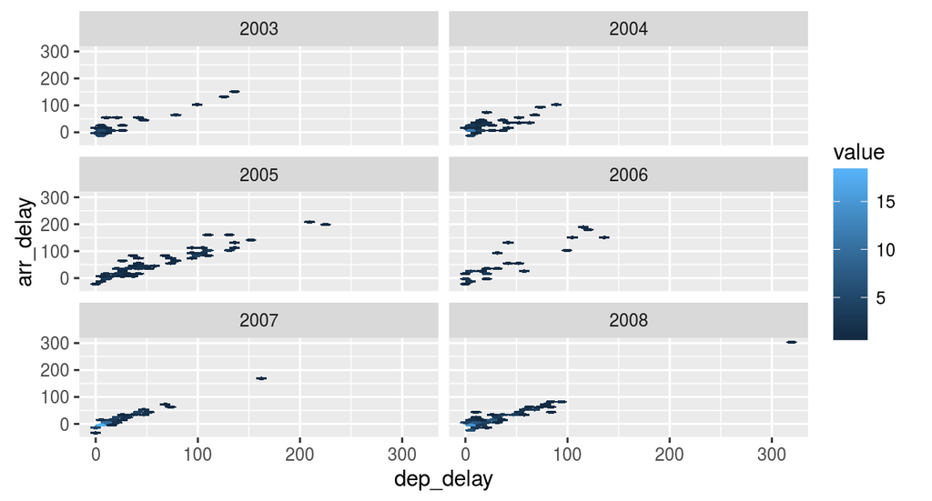

```r
pl <- ggplot(ontime_dep_delay , aes(dep_delay, arr_delay))
pl <- pl + stat_binhex(bins = 30) + facet_wrap(~year, ncol = 2)
print(pl)
```